# Visualización de Redes

## Despliegue gráfico de redes

### Datos 1: *data frame*

Ahora que tenemos el objeto *igraph*, hagamos un primer intento para graficarlo.

```r
plot(net)
```

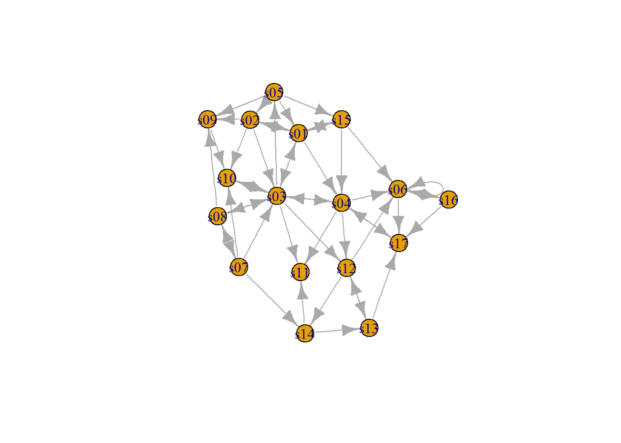

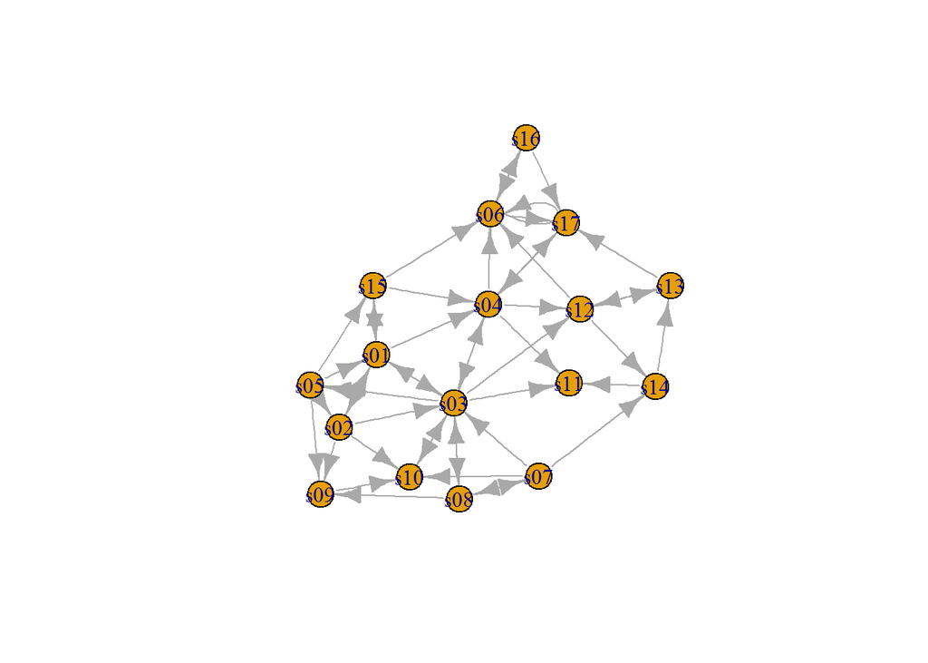

No se ve muy bonita. Empecemos por arreglarla eliminando los “loops” en el grafo. Podemos usar `simplify(net, edge.attr.comb=list(Weight="sum","ignore"))` para combinar múltiples arcos y sumar sus pesos. Lo malo de hacer eso es que así se combinan los distintos tipos de arcos (en nuestro ejemplo *hyperlinks* y *mentions*). Por lo tanto optamos, en este caso, por no combinar los múltiples arcos con el comando:

```r
net <- simplify(net, remove.multiple = F, remove.loops = T)
```

El tamaño de las flechas parece excesivo, así que lo reducimos y eliminamos las etiquetas de los nodos.

```r
plot(net, edge.arrow.size=.4,vertex.label=NA)
```

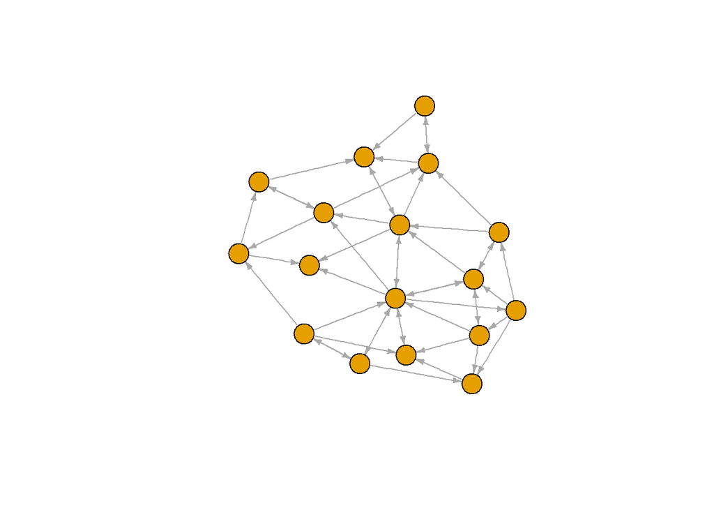

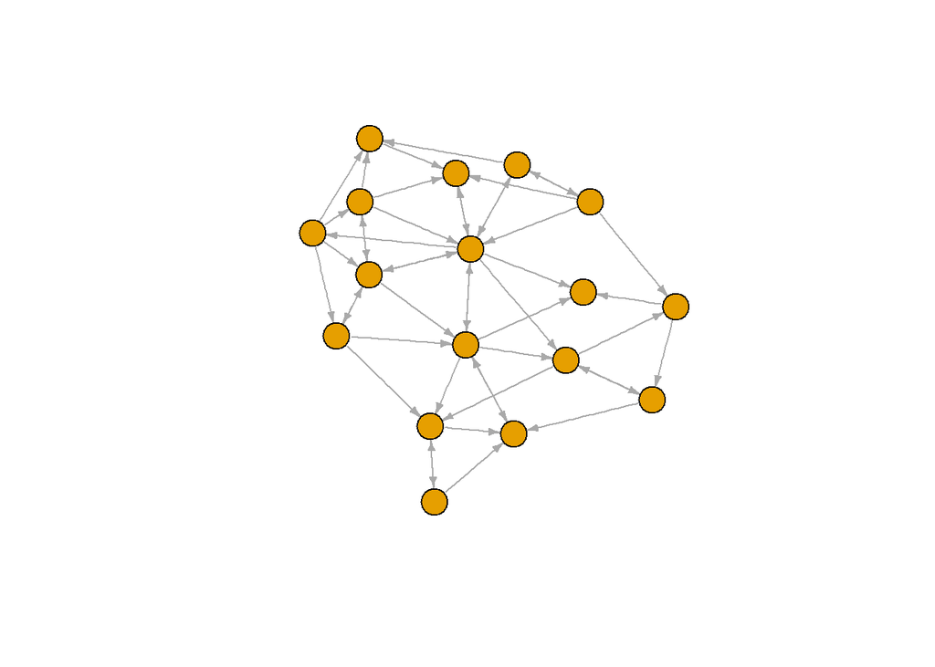

### Datos 2: matriz

Ahora, los datos de ejemplo 2 están en formato matricial y describen una red *bipartita*. Podemos crear un objeto *igraph* con la función `graph_from_incidence_matrix()`. En este caso, una red *bipartita*, los nodos tienen un atributo *tipo* que es **FALSE** en los vértices que pertenecen al modo “1” y **TRUE** para los nodos que pertenencen al otro tipo. En el caso de redes normales (*unipartitas* digamos), se usa la función `graph_from_adjacency_matrix()`

```r
head(nodes2)
```

```
##    id   media media.type media.name audience.size
## 1 s01     NYT          1  Newspaper            20
## 2 s02    WaPo          1  Newspaper            25
## 3 s03     WSJ          1  Newspaper            30
## 4 s04    USAT          1  Newspaper            32
## 5 s05 LATimes          1  Newspaper            20
## 6 s06     CNN          2         TV            56
```

```r
head(links2)
```

```
##     U01 U02 U03 U04 U05 U06 U07 U08 U09 U10 U11 U12 U13 U14 U15 U16 U17
## s01   1   1   1   0   0   0   0   0   0   0   0   0   0   0   0   0   0
## s02   0   0   0   1   1   0   0   0   0   0   0   0   0   0   0   0   0
## s03   0   0   0   0   0   1   1   1   1   0   0   0   0   0   0   0   0
## s04   0   0   0   0   0   0   0   0   1   1   1   0   0   0   0   0   0
## s05   0   0   0   0   0   0   0   0   0   0   1   1   1   0   0   0   0
## s06   0   0   0   0   0   0   0   0   0   0   0   0   1   1   0   0   1
##     U18 U19 U20
## s01   0   0   0
## s02   0   0   1
## s03   0   0   0
## s04   0   0   0
## s05   0   0   0
## s06   0   0   0
```

```r
net2 <- graph_from_incidence_matrix(links2)
table(V(net2)$type)
```

```
##
## FALSE  TRUE
##    10    20
```

## Parámetros de graficación

El despliegue de grafos con *igraph* tiene un amplio conjunto de parámetros que se pueden utilizar. Incluyen opciones para los nodos (usan la palabra *vertex*) y los arcos (usan la palabra *edge*).

Podemos personalizar el grafo de dos maneras. Una es especificar los parámetros en la misma función `plot`. Por ejemplo, hagamos que la gráfica tenga arcos curvos y flechas pequeñas. Al hacer eso es más facil ver enlaces múltiples entre dos nodos dados.

```r
plot(net, edge.arrow.size=.4, edge.curved=.1)
```

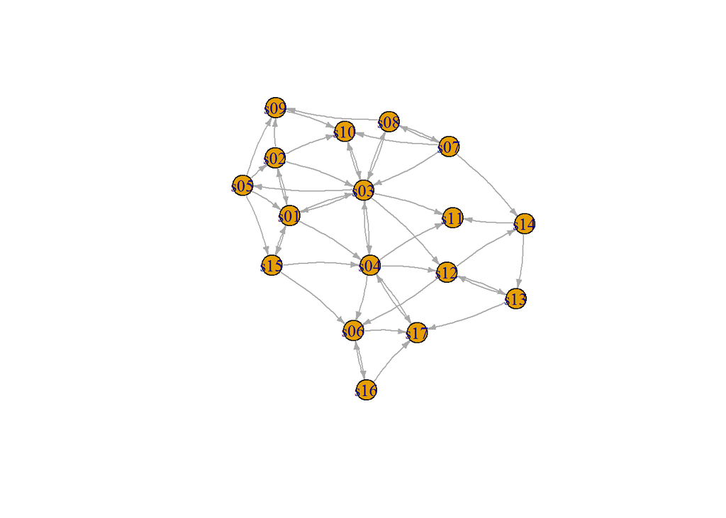

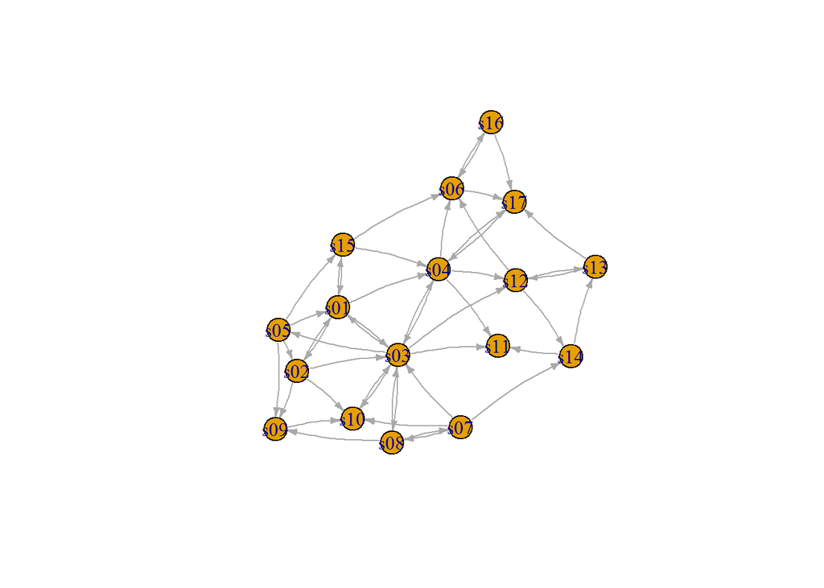

```r
plot(net, edge.arrow.size=.2, edge.color="orange",
     vertex.color="orange", vertex.frame.color="#ffffff",
     vertex.label=V(net)$media, vertex.label.color="black")
```

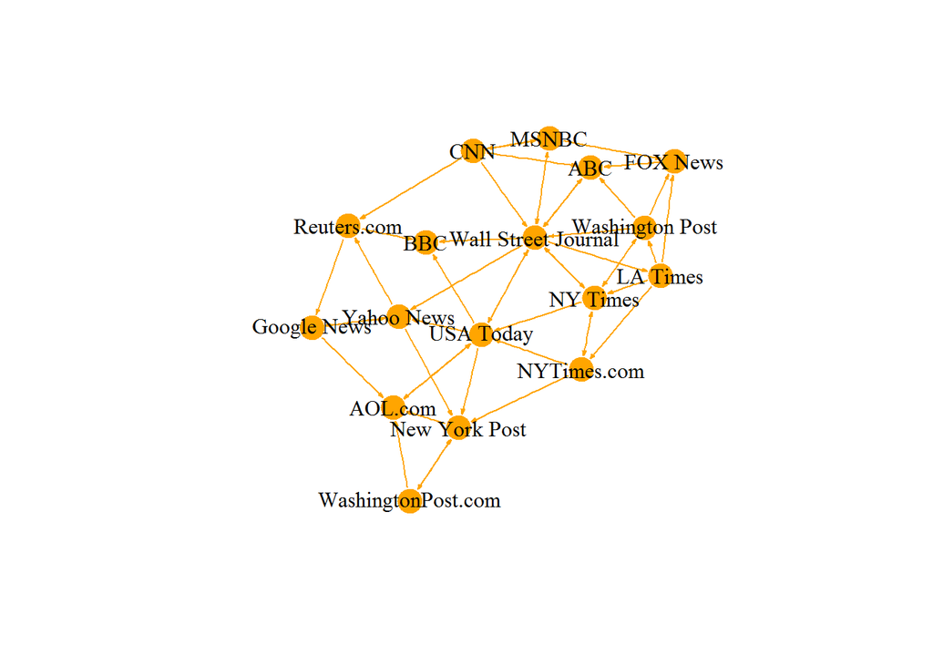

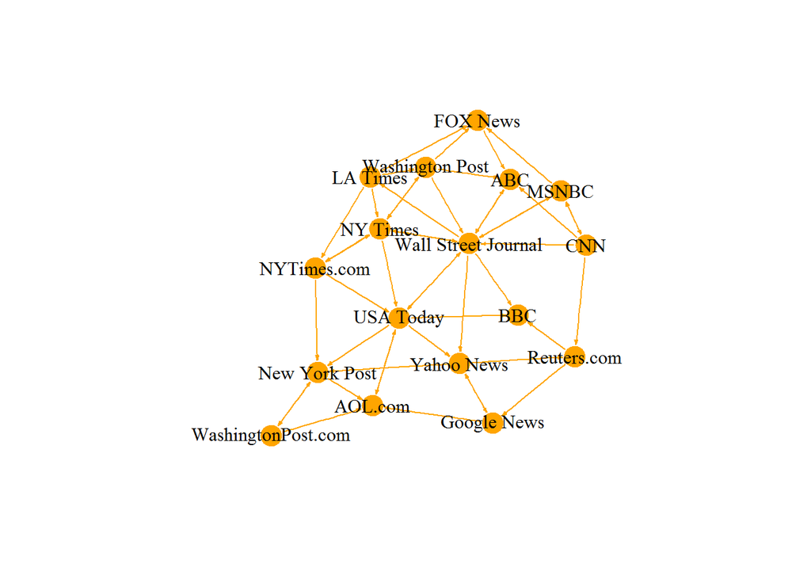

#### Colores según el tipo de *medio*

```r
colrs <- c("gray50", "tomato", "gold")
V(net)$color <- colrs[V(net)$media.type]
```

#### Calcula el *grado* de los nodos

```r
deg <- degree(net, mode="all")
V(net)$size <- deg*3
```

#### Valor del tamaño de la audiencia de cada medio

```r
V(net)$size <- V(net)$audience.size*0.6
```

#### Eliminar etiquetas

Las etiquetas aparecen por default asociadas con el ID del nodo. Para eliminarlas simplemente hay que cambiar el atributo *label* a **NA**.

```r
V(net)$label <- NA
```

#### Tamaño del arco proporcional a su peso

```r
E(net)$width <- E(net)$weight/6
```

#### Ajuste del tamaño y color de la flecha

```r
E(net)$arrow.size <- .2
E(net)$edge.color <- "gray80"
E(net)$width <- 1+E(net)$weight/12
```

#### Despliegue de la red con los nuevos parámetros

```r
plot(net)
```

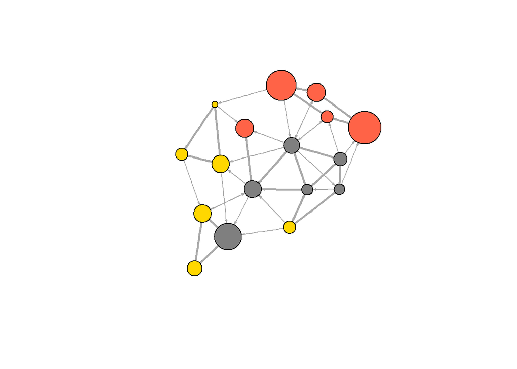

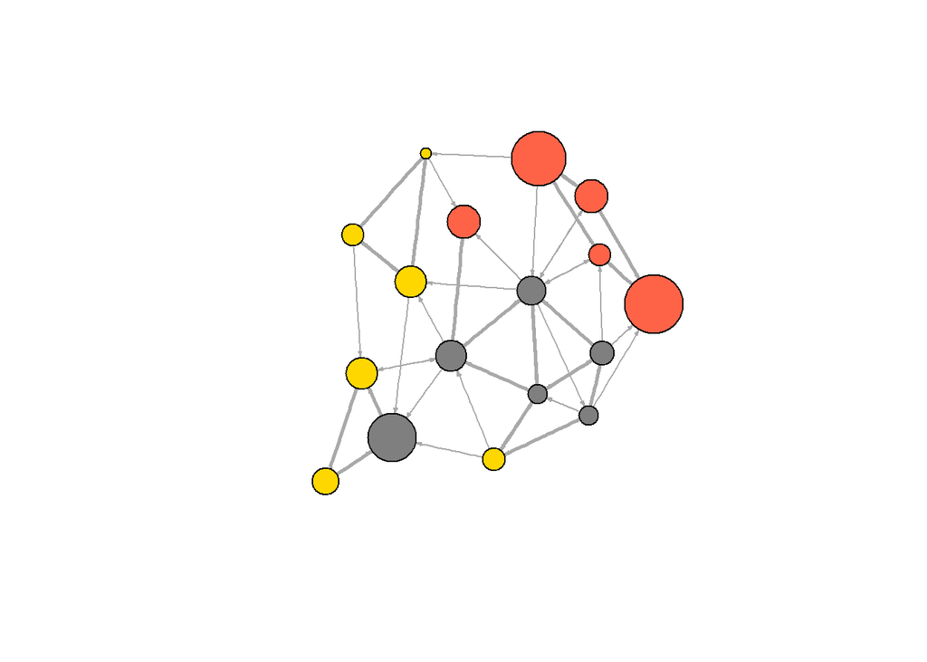

#### Añadir leyenda

La lectura del grafo mejora si agregamos una leyenda explicativa. Además podemos mostrar agrupamiento de nodos. *igraph* puede identificar **comunidades** a partir de la propagación de las etiquetas con la función `cluster_label_prop`. El resultado de esta identificación de comunidades crea un objeto de agrupamiento que *igraph* sabe como graficar.

```r
# Community detection based on label propagation:
clp <- cluster_label_prop(net)
class(clp)
```

```
## [1] "communities"
```

```r
colrs <- adjustcolor( c("gray50", "tomato", "gold", "yellowgreen"), alpha=.6)
plot(clp, net)

legend(x=-1.5, y=-1.1, c("Newspaper","Television", "Online News"), pch=21,
       col="#777777", pt.bg=colrs, pt.cex=2, cex=.8, bty="n", ncol=1)
```

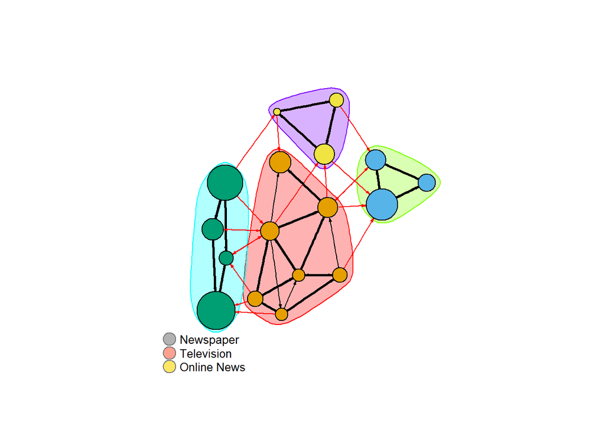

#### Títulos de nodo en lugar de figuras

En ocasiones es mejor usar el descriptor o identificador de los nodos como identificación en la gráfica. esto se hace como sigue en R

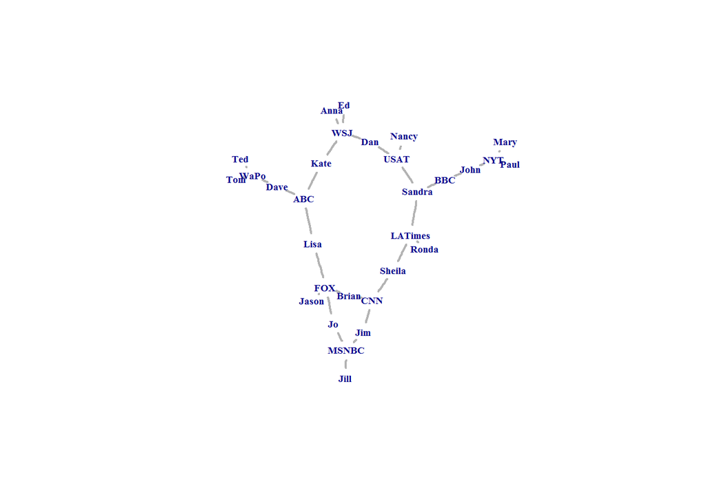

```r
plot(net2, vertex.shape="none", vertex.label=nodes2$media,
     vertex.label.color=V(net2)$color, vertex.label.font=2,
     vertex.label.cex=.6, edge.color="gray70",  edge.width=2)
```

#### Usar imágenes para ilustrar nodos

Otra opciónatractiva es la posibilidad de utilizar imágenes para representar los nodos. Esto puede hacerce con relativa facilidad en R como sigue.

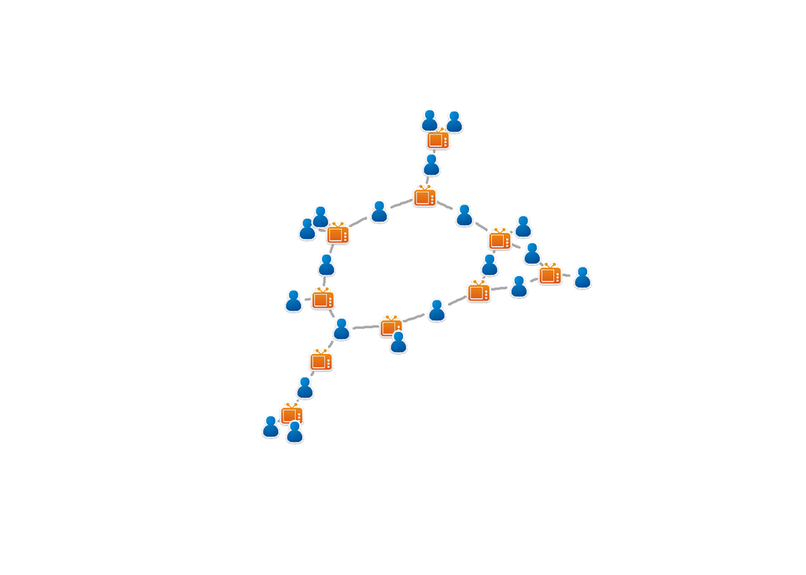

```r
# install.packages('png')
library('png')

img.1 <- readPNG("./images/news.png")
img.2 <- readPNG("./images/user.png")

V(net2)$raster <- list(img.1, img.2)[V(net2)$type+1]

plot(net2, vertex.shape="raster", vertex.label=NA,
     vertex.size=16, vertex.size2=16, edge.width=2)
```

[figure not shown]